# Ford GoBike System Data Exploration

## Preliminary Wrangling

> This document discusses the dataset that contains information about individual rides made in a bike-sharing system covering the greater San Francisco Bay area. The data set contains 183412 trips 16 features.

```python
# import all packages and set plots to be embedded inline
import numpy as np
import pandas as pd
import matplotlib.pyplot as plt
import seaborn as sb

%matplotlib inline
```

```python
# load in the dataset into a pandas dataframe
df = pd.read_csv('201902-fordgobike-tripdata.csv')
```

```python
df.head()
```

|  | duration_sec | start_time | end_time | start_station_id | start_station_name | start_station_latitude | start_station_longitude | end_station_id | end_station_name | end_station_latitude | end_station_longitude | bike_id | user_type | member_birth_year | member_gender | bike_share_for_all_trip |
| --- | --- | --- | --- | --- | --- | --- | --- | --- | --- | --- | --- | --- | --- | --- | --- | --- |
| 0 | 52185 | 2019-02-28 17:32:10.1450 | 2019-03-01 08:01:55.9750 | 21.0 | Montgomery St BART Station (Market St at 2nd St) | 37.789625 | -122.400811 | 13.0 | Commercial St at Montgomery St | 37.794231 | -122.402923 | 4902 | Customer | 1984.0 | Male | No |
| 1 | 42521 | 2019-02-28 18:53:21.7890 | 2019-03-01 06:42:03.0560 | 23.0 | The Embarcadero at Steuart St | 37.791464 | -122.391034 | 81.0 | Berry St at 4th St | 37.775880 | -122.393170 | 2535 | Customer | NaN | NaN | No |
| 2 | 61854 | 2019-02-28 12:13:13.2180 | 2019-03-01 05:24:08.1460 | 86.0 | Market St at Dolores St | 37.769305 | -122.426826 | 3.0 | Powell St BART Station (Market St at 4th St) | 37.786375 | -122.404904 | 5905 | Customer | 1972.0 | Male | No |
| 3 | 36490 | 2019-02-28 17:54:26.0100 | 2019-03-01 04:02:36.8420 | 375.0 | Grove St at Masonic Ave | 37.774836 | -122.446546 | 70.0 | Central Ave at Fell St | 37.773311 | -122.444293 | 6638 | Subscriber | 1989.0 | Other | No |
| 4 | 1585 | 2019-02-28 23:54:18.5490 | 2019-03-01 00:20:44.0740 | 7.0 | Frank H Ogawa Plaza | 37.804562 | -122.271738 | 222.0 | 10th Ave at E 15th St | 37.792714 | -122.248780 | 4898 | Subscriber | 1974.0 | Male | Yes |

```python
df.shape
```

```
(183412, 16)
```

```python
# information content
df.info()
```

```
<class 'pandas.core.frame.DataFrame'>
RangeIndex: 183412 entries, 0 to 183411
Data columns (total 16 columns):
duration_sec               183412 non-null int64
start_time                 183412 non-null object
end_time                   183412 non-null object
start_station_id           183215 non-null float64
start_station_name         183215 non-null object
start_station_latitude     183412 non-null float64
start_station_longitude    183412 non-null float64
end_station_id             183215 non-null float64
end_station_name           183215 non-null object
end_station_latitude       183412 non-null float64
end_station_longitude      183412 non-null float64
bike_id                    183412 non-null int64
user_type                  183412 non-null object
member_birth_year          175147 non-null float64
member_gender              175147 non-null object
bike_share_for_all_trip    183412 non-null object
dtypes: float64(7), int64(2), object(7)
memory usage: 22.4+ MB
```

### What is the structure of your dataset?

The Ford GoBike System Dataset consists of 183412 bike rides and, include the 16 following columns:

- Duration Trips (in seconds)
- Start Date and Time
- End Date and Time
- Start Station ID
- Start Station Name
- Start Station Latitude
- Start Station Longitude
- End Station ID
- End Station Name
- End Station Latitude
- End Station Longitude
- Bike ID
- User Type (Subscriber or Customer)
- member birth year
- member_gender
- bike_share_for_all_trip

### What is/are the main feature(s) of interest in your dataset?

> The number of trips and the duration of the travel, and how they depend on other features.

### What features in the dataset do you think will help support your investigation into your feature(s) of interest?

> I think that the members gender, members ages, and the user type have clear associations with the number of trips and the duration of the trips.

```python
df.info()
```

```
<class 'pandas.core.frame.DataFrame'>
RangeIndex: 183412 entries, 0 to 183411
Data columns (total 16 columns):
duration_sec               183412 non-null int64
start_time                 183412 non-null object
end_time                   183412 non-null object
start_station_id           183215 non-null float64
start_station_name         183215 non-null object
start_station_latitude     183412 non-null float64
start_station_longitude    183412 non-null float64
end_station_id             183215 non-null float64
end_station_name           183215 non-null object
end_station_latitude       183412 non-null float64
end_station_longitude      183412 non-null float64
bike_id                    183412 non-null int64
user_type                  183412 non-null object
member_birth_year          175147 non-null float64
member_gender              175147 non-null object
bike_share_for_all_trip    183412 non-null object
dtypes: float64(7), int64(2), object(7)
memory usage: 22.4+ MB
```

```python
# Features Statistics
display(df.describe())
```

|  | duration_sec | start_station_id | start_station_latitude | start_station_longitude | end_station_id | end_station_latitude | end_station_longitude | bike_id | member_birth_year |
| --- | --- | --- | --- | --- | --- | --- | --- | --- | --- |
| count | 183412.000000 | 183215.000000 | 183412.000000 | 183412.000000 | 183215.000000 | 183412.000000 | 183412.000000 | 183412.000000 | 175147.000000 |
| mean | 726.078435 | 138.590427 | 37.771223 | -122.352664 | 136.249123 | 37.771427 | -122.352250 | 4472.906375 | 1984.806437 |
| std | 1794.389780 | 111.778864 | 0.099581 | 0.117097 | 111.515131 | 0.099490 | 0.116673 | 1664.383394 | 10.116689 |
| min | 61.000000 | 3.000000 | 37.317298 | -122.453704 | 3.000000 | 37.317298 | -122.453704 | 11.000000 | 1878.000000 |
| 25% | 325.000000 | 47.000000 | 37.770083 | -122.412408 | 44.000000 | 37.770407 | -122.411726 | 3777.000000 | 1980.000000 |
| 50% | 514.000000 | 104.000000 | 37.780760 | -122.398285 | 100.000000 | 37.781010 | -122.398279 | 4958.000000 | 1987.000000 |
| 75% | 796.000000 | 239.000000 | 37.797280 | -122.286533 | 235.000000 | 37.797320 | -122.288045 | 5502.000000 | 1992.000000 |
| max | 85444.000000 | 398.000000 | 37.880222 | -121.874119 | 398.000000 | 37.880222 | -121.874119 | 6645.000000 | 2001.000000 |

```python
# Is there a duplicated values?
df.duplicated().any()
```

```
False
```

```python
# count the missing values
df.isna().sum()
```

```
duration_sec                  0
start_time                    0
end_time                      0
start_station_id            197
start_station_name          197
start_station_latitude        0
start_station_longitude       0
end_station_id              197
end_station_name            197
end_station_latitude          0
end_station_longitude         0
bike_id                       0
user_type                     0
member_birth_year          8265
member_gender              8265
bike_share_for_all_trip       0
dtype: int64
```

```python
df['age'] = 2019 - df.member_birth_year
```

```python
df.dropna(subset=['age'], inplace= True)
```

```python
df.isna().sum()
```

```
duration_sec                 0
start_time                   0
end_time                     0
start_station_id           195
start_station_name         195
start_station_latitude       0
start_station_longitude      0
end_station_id             195
end_station_name           195
end_station_latitude         0
end_station_longitude        0
bike_id                      0
user_type                    0
member_birth_year            0
member_gender                0
bike_share_for_all_trip      0
age                          0
dtype: int64
```

```python
bins = [0, 25, 45, 65, np.inf]
names = ['Youth', 'Younger Adults','Older Adults','Seniors']

df['AgeRanges'] = pd.cut(df['age'], bins, labels=names)
```

```python
df.head(10)
```

|  | duration_sec | start_time | end_time | start_station_id | start_station_name | start_station_latitude | start_station_longitude | end_station_id | end_station_name | end_station_latitude | end_station_longitude | bike_id | user_type | member_birth_year | member_gender | bike_share_for_all_trip | age | AgeRanges |
| --- | --- | --- | --- | --- | --- | --- | --- | --- | --- | --- | --- | --- | --- | --- | --- | --- | --- | --- |
| 0 | 52185 | 2019-02-28 17:32:10.1450 | 2019-03-01 08:01:55.9750 | 21.0 | Montgomery St BART Station (Market St at 2nd St) | 37.789625 | -122.400811 | 13.0 | Commercial St at Montgomery St | 37.794231 | -122.402923 | 4902 | Customer | 1984.0 | Male | No | 35.0 | Younger Adults |
| 2 | 61854 | 2019-02-28 12:13:13.2180 | 2019-03-01 05:24:08.1460 | 86.0 | Market St at Dolores St | 37.769305 | -122.426826 | 3.0 | Powell St BART Station (Market St at 4th St) | 37.786375 | -122.404904 | 5905 | Customer | 1972.0 | Male | No | 47.0 | Older Adults |
| 3 | 36490 | 2019-02-28 17:54:26.0100 | 2019-03-01 04:02:36.8420 | 375.0 | Grove St at Masonic Ave | 37.774836 | -122.446546 | 70.0 | Central Ave at Fell St | 37.773311 | -122.444293 | 6638 | Subscriber | 1989.0 | Other | No | 30.0 | Younger Adults |
| 4 | 1585 | 2019-02-28 23:54:18.5490 | 2019-03-01 00:20:44.0740 | 7.0 | Frank H Ogawa Plaza | 37.804562 | -122.271738 | 222.0 | 10th Ave at E 15th St | 37.792714 | -122.248780 | 4898 | Subscriber | 1974.0 | Male | Yes | 45.0 | Younger Adults |
| 5 | 1793 | 2019-02-28 23:49:58.6320 | 2019-03-01 00:19:51.7600 | 93.0 | 4th St at Mission Bay Blvd S | 37.770407 | -122.391198 | 323.0 | Broadway at Kearny | 37.798014 | -122.405950 | 5200 | Subscriber | 1959.0 | Male | No | 60.0 | Older Adults |
| 6 | 1147 | 2019-02-28 23:55:35.1040 | 2019-03-01 00:14:42.5880 | 300.0 | Palm St at Willow St | 37.317298 | -121.884995 | 312.0 | San Jose Diridon Station | 37.329732 | -121.901782 | 3803 | Subscriber | 1983.0 | Female | No | 36.0 | Younger Adults |
| 7 | 1615 | 2019-02-28 23:41:06.7660 | 2019-03-01 00:08:02.7560 | 10.0 | Washington St at Kearny St | 37.795393 | -122.404770 | 127.0 | Valencia St at 21st St | 37.756708 | -122.421025 | 6329 | Subscriber | 1989.0 | Male | No | 30.0 | Younger Adults |
| 8 | 1570 | 2019-02-28 23:41:48.7900 | 2019-03-01 00:07:59.7150 | 10.0 | Washington St at Kearny St | 37.795393 | -122.404770 | 127.0 | Valencia St at 21st St | 37.756708 | -122.421025 | 6548 | Subscriber | 1988.0 | Other | No | 31.0 | Younger Adults |
| 9 | 1049 | 2019-02-28 23:49:47.6990 | 2019-03-01 00:07:17.0250 | 19.0 | Post St at Kearny St | 37.788975 | -122.403452 | 121.0 | Mission Playground | 37.759210 | -122.421339 | 6488 | Subscriber | 1992.0 | Male | No | 27.0 | Younger Adults |
| 10 | 458 | 2019-02-28 23:57:57.2110 | 2019-03-01 00:05:35.4350 | 370.0 | Jones St at Post St | 37.787327 | -122.413278 | 43.0 | San Francisco Public Library (Grove St at Hyde... | 37.778768 | -122.415929 | 5318 | Subscriber | 1996.0 | Female | Yes | 23.0 | Youth |

## Univariate Exploration

### What is the most frequent age category does trips?

```python
type_counts = df.AgeRanges.value_counts(sort=True)
type_order = type_counts.index
n_trips = type_counts.sum()
```

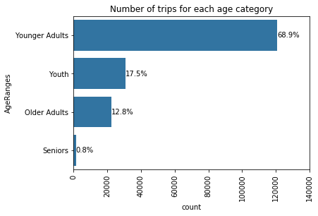

```python
# Choose the first tuple of RGB colors
base_color = sb.color_palette()[0]

sb.countplot(data= df, y='AgeRanges', color=base_color, order=type_order);

# Logic to print the proportion text on the bars
for i in range(len(type_counts)):
    count = type_counts[type_order[i]]
    # Convert count into a percentage, and then into string
    age_string = '{:0.1f}%'.format(100 * count/n_trips)
    # Print the string value on the bar.
    plt.text(count+1, i, age_string, va='center', color = 'black')

plt.title('Number of trips for each age category')
plt.xticks(rotation=90);
plt.xlim([0, 140000]);
```

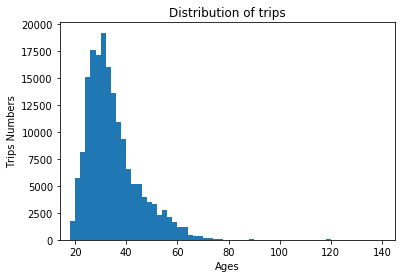

```python
# Numbers of Trips distribution accorading to age.
bins = np.arange(df['age'].min()-4, df['age'].max()+2, 2)
plt.hist(data = df, x = 'age', bins = bins);
plt.title('Distribution of trips')
plt.xlabel('Ages')
plt.ylabel('Trips Numbers')
plt.xlim([df['age'].min()-4, df['age'].max()+4])
plt.show()
```

### What is the most frequent gender type does trips?

```python
sorted_counts = df.member_gender.value_counts()
n_trips = sorted_counts.sum()
```

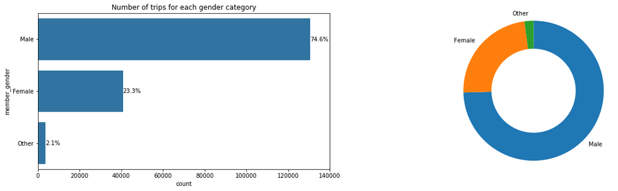

```python
# Resize the chart, and have two plots side-by-side
# Set a larger figure size for subplots
plt.figure(figsize = [20, 5])

# 1 row, 2 cols, subplot 1
plt.subplot(1, 2, 1)
base_color = sb.color_palette()[0]
sb.countplot(data= df, y='member_gender', color=base_color, order=sorted_counts.index);

# Logic to print the proportion text on the bars
for i in range(len(sorted_counts)):
    count = sorted_counts[sorted_counts.index[i]]
    # Convert count into a percentage, and then into string
    age_string = '{:0.1f}%'.format(100 * count/n_trips)
    # Print the string value on the bar.
    plt.text(count+1, i, age_string, va='center', color = 'black')
plt.xlim([0, 140000])
plt.title('Number of trips for each gender category');

plt.subplot(1, 2, 2) # 1 row, 2 cols, subplot 2
plt.pie(sorted_counts, labels =sorted_counts.index, startangle = 90,
        counterclock = False, wedgeprops = {'width' : 0.4});
plt.axis('square');
```

- According to this visualizes, It's obvious that the most gender category has trips is **Male** where **74.6%** of the total trips.

### which users type mostly have more trips?

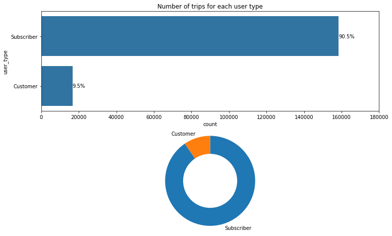

```python
sorted_counts = df['user_type'].value_counts()

# Resize the chart, and have two plots side-by-side
# Set a larger figure size for subplots
plt.figure(figsize = [12, 8])

# 1 row, 2 cols, subplot 1
plt.subplot(2, 1, 1)
base_color = sb.color_palette()[0]
sb.countplot(data= df, y='user_type', color=base_color, order=sorted_counts.index);

# Logic to print the proportion text on the bars
for i in range(len(sorted_counts)):
    count = sorted_counts[sorted_counts.index[i]]
    # Convert count into a percentage, and then into string
    age_string = '{:0.1f}%'.format(100 * count/n_trips)
    # Print the string value on the bar.
    plt.text(count+1, i, age_string, va='center', color = 'black')
plt.xlim([0, 180000]);
plt.title('Number of trips for each user type');

plt.subplot(2, 1, 2) # 1 row, 2 cols, subplot 2
plt.pie(sorted_counts, labels =sorted_counts.index, startangle = 90,
        counterclock = False, wedgeprops = {'width' : 0.4});
plt.axis('square');
```

It appears like subscribers have more trips than consumers where **90.5%** of the participants are subscribers.

### What is the most time Duration frequence in Seconds?

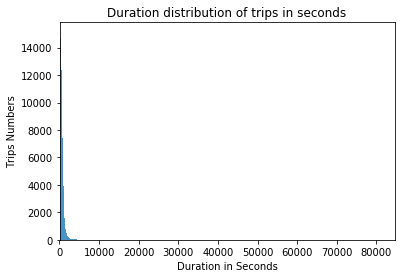

```python
# Distribution of Trip Durations in sconds
bins = np.arange(df['duration_sec'].min(), df['duration_sec'].max()+60, 60)
sb.distplot(df['duration_sec'], bins = bins, kde = False, hist_kws = {'alpha' : 0.8});
plt.title('Duration distribution of trips in seconds')
plt.xlabel('Duration in Seconds')
plt.ylabel('Trips Numbers')
plt.xlim([df['duration_sec'].min(), df['duration_sec'].max()])
plt.show()
```

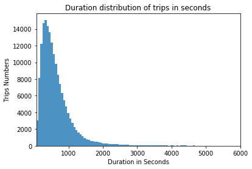

```python
# Distribution of Trip Durations in sconds
bins = np.arange(df['duration_sec'].min(), df['duration_sec'].max()+60, 60)
sb.distplot(df['duration_sec'], bins = bins, kde = False, hist_kws = {'alpha' : 0.8});
plt.title('Duration distribution of trips in seconds')
plt.xlabel('Duration in Seconds')
plt.ylabel('Trips Numbers')
plt.xlim([df['duration_sec'].min(), 6000])
plt.show()
```

the most time duration frequence in seconds is **300-600** seconds.

```python
# Converting datetime columns(start time, end time) to pandas datetime object.
df.start_time, df.end_time = pd.to_datetime(df.start_time), pd.to_datetime(df.end_time)
df.info()
```

```
<class 'pandas.core.frame.DataFrame'>
Int64Index: 175147 entries, 0 to 183411
Data columns (total 18 columns):
duration_sec               175147 non-null int64
start_time                 175147 non-null datetime64[ns]
end_time                   175147 non-null datetime64[ns]
start_station_id           174952 non-null float64
start_station_name         174952 non-null object
start_station_latitude     175147 non-null float64
start_station_longitude    175147 non-null float64
end_station_id             174952 non-null float64
end_station_name           174952 non-null object
end_station_latitude       175147 non-null float64
end_station_longitude      175147 non-null float64
bike_id                    175147 non-null int64
user_type                  175147 non-null object
member_birth_year          175147 non-null float64
member_gender              175147 non-null object
bike_share_for_all_trip    175147 non-null object
age                        175147 non-null float64
AgeRanges                  175147 non-null category
dtypes: category(1), datetime64[ns](2), float64(8), int64(2), object(5)
memory usage: 29.2+ MB
```

```python
# Extract more useful columns
df['start_time_day']= df.start_time.dt.day
df['start_time_day_name']= df['start_time'].dt.day_name()
df.head()
```

|  | duration_sec | start_time | end_time | start_station_id | start_station_name | start_station_latitude | start_station_longitude | end_station_id | end_station_name | end_station_latitude | end_station_longitude | bike_id | user_type | member_birth_year | member_gender | bike_share_for_all_trip | age | AgeRanges | start_time_day | start_time_day_name |
| --- | --- | --- | --- | --- | --- | --- | --- | --- | --- | --- | --- | --- | --- | --- | --- | --- | --- | --- | --- | --- |
| 0 | 52185 | 2019-02-28 17:32:10.145 | 2019-03-01 08:01:55.975 | 21.0 | Montgomery St BART Station (Market St at 2nd St) | 37.789625 | -122.400811 | 13.0 | Commercial St at Montgomery St | 37.794231 | -122.402923 | 4902 | Customer | 1984.0 | Male | No | 35.0 | Younger Adults | 28 | Thursday |
| 2 | 61854 | 2019-02-28 12:13:13.218 | 2019-03-01 05:24:08.146 | 86.0 | Market St at Dolores St | 37.769305 | -122.426826 | 3.0 | Powell St BART Station (Market St at 4th St) | 37.786375 | -122.404904 | 5905 | Customer | 1972.0 | Male | No | 47.0 | Older Adults | 28 | Thursday |
| 3 | 36490 | 2019-02-28 17:54:26.010 | 2019-03-01 04:02:36.842 | 375.0 | Grove St at Masonic Ave | 37.774836 | -122.446546 | 70.0 | Central Ave at Fell St | 37.773311 | -122.444293 | 6638 | Subscriber | 1989.0 | Other | No | 30.0 | Younger Adults | 28 | Thursday |
| 4 | 1585 | 2019-02-28 23:54:18.549 | 2019-03-01 00:20:44.074 | 7.0 | Frank H Ogawa Plaza | 37.804562 | -122.271738 | 222.0 | 10th Ave at E 15th St | 37.792714 | -122.248780 | 4898 | Subscriber | 1974.0 | Male | Yes | 45.0 | Younger Adults | 28 | Thursday |
| 5 | 1793 | 2019-02-28 23:49:58.632 | 2019-03-01 00:19:51.760 | 93.0 | 4th St at Mission Bay Blvd S | 37.770407 | -122.391198 | 323.0 | Broadway at Kearny | 37.798014 | -122.405950 | 5200 | Subscriber | 1959.0 | Male | No | 60.0 | Older Adults | 28 | Thursday |

### Which days in the week have more trips?

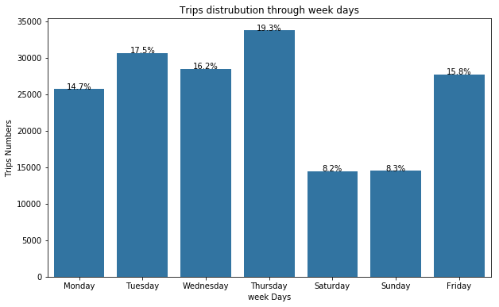

```python
# Distribution of Trip through week days
plt.figure(figsize=[10, 6])
sorted_counts = df['start_time_day_name'].value_counts(sort=False)
n_trips = sorted_counts.sum()

base_color = sb.color_palette()[0]
start_time_day_name_order = df['start_time_day_name'].value_counts(sort=False).index
sb.countplot(data=df, x='start_time_day_name', order=start_time_day_name_order, color=base_color)

# get the current tick locations and labels
locs, labels = plt.xticks()

# loop through each pair of locations and labels
for loc, label in zip(locs, labels):
    # get the text property for the label to get the correct count
    count = sorted_counts[label.get_text()]
    # Convert count into a percentage, and then into string
    age_string = '{:0.1f}%'.format(100 * count/n_trips)
    # Print the string value on the bar.
    plt.text(loc, count+2, age_string, ha = 'center', color = 'black')

plt.xlabel('week Days')
plt.ylabel('Trips Numbers')
plt.title('Trips distrubution through week days');
```

It seems that the number of trips in **(Thursday-Tuesday-Wednesday)** appears to be higher than the number of **(Sunday-Saturday)**.

## Bivariate Exploration

> In this section, investigate relationships between pairs of variables in your data. Make sure the variables that you cover here have been introduced in some fashion in the previous section (univariate exploration).

### Plot the longitude and the latitude of the Start stations:

### How is it important to consider "longitude" and "latitude" of the start and end stations in our analysis?

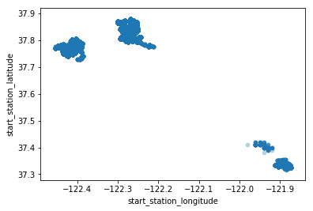

```python
sorted_counts = df['start_station_name'].value_counts()
df.plot(kind='scatter', x= 'start_station_longitude', y='start_station_latitude', alpha=0.3)
plt.legend()
```

### Plot the longitude and the latitude of the End stations:

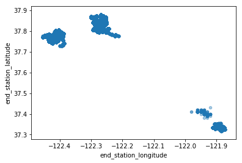

```python
sorted_counts = df['end_station_name'].value_counts()
n_trips = sorted_counts.sum()
df.plot(kind='scatter', x= 'end_station_longitude', y='end_station_latitude', alpha=0.4)
plt.legend()
```

I thik that the end and start stations are not distrubuted uniformally thoughout the entire city, Its consintrated in distincted places in the city. I have tries to get some insights of these plots but I don't think that "latitude" and "Longitude" features are important in our analysis.

### the Relation between member gender and age categories:

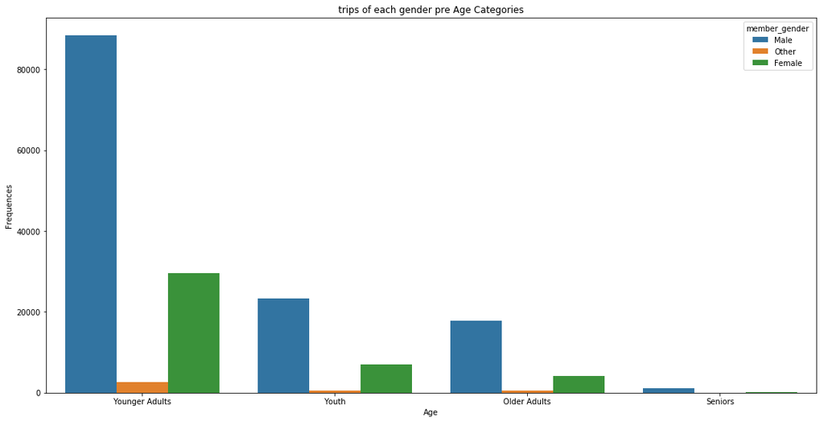

```python
plt.figure(figsize = [18, 9])
member_Ages_categories_order = df['AgeRanges'].value_counts().index
sb.countplot(data=df, x='AgeRanges', hue='member_gender', order= member_Ages_categories_order);
plt.title('trips of each gender pre Age Categories')
plt.xlabel('Age');
plt.ylabel('Frequences');
```

- It's seems that the Male younger Adults has the most trips.

### The Average duration time according to Member Gender:

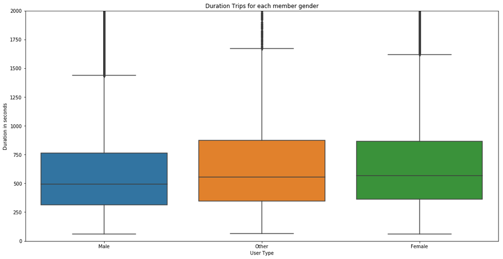

```python
# Distribution of Trip Duration for each User Type
plt.figure(figsize = [18, 9])
sb.boxplot(data=df, x='member_gender', y='duration_sec')
plt.title('Duration Trips for each member gender')
plt.xlabel('User Type')
plt.ylabel('Duration in seconds')
plt.ylim([-1, 2000])
plt.show()
```

- according to this visualize, the male gender has less average duration trip.

### the Distribution of Trip Duration for each User Type

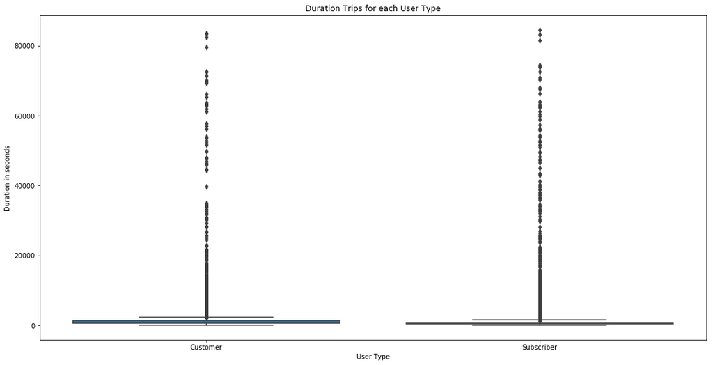

```python
# Distribution of Trip Duration for each User Type
plt.figure(figsize = [18, 9])
sb.boxplot(data=df, x='user_type', y='duration_sec')
plt.title('Duration Trips for each User Type')
plt.xlabel('User Type')
plt.ylabel('Duration in seconds')
plt.show()
```

From the above observation, Y-axis is large in scale, and we'll get better results if we limit the y-axis to 2000 seconds, since most of the trips took less than 2000 seconds.

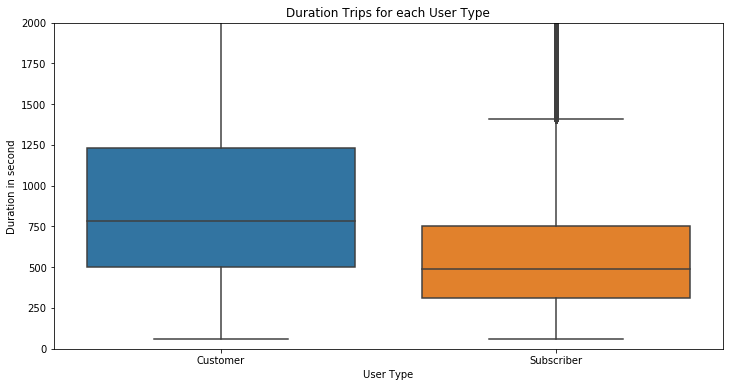

```python
# Distribution of trip Duration for each User Type

plt.figure(figsize = [12, 6])
sb.boxplot(data=df, x='user_type', y='duration_sec')
plt.ylim([-1, 2000])
plt.title('Duration Trips for each User Type')
plt.xlabel('User Type')
plt.ylabel('Duration in second')
plt.show()
```

It seems like Consumers are more likely than Subscribers to make longer Trips.

### what is the Distribution of the trips of each user type pre week?

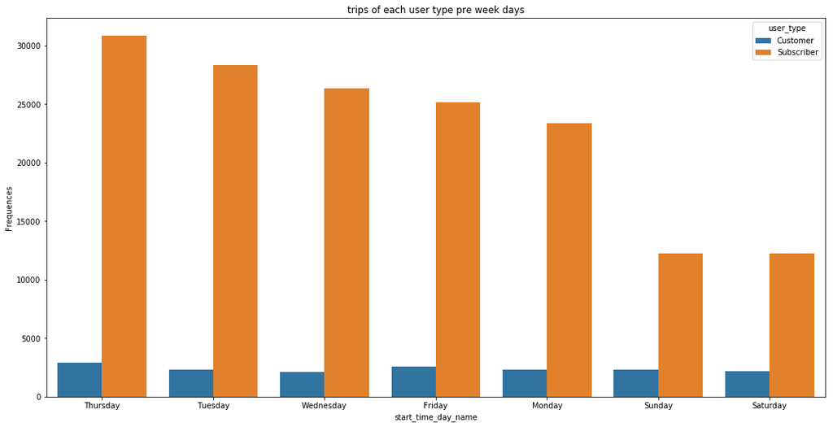

```python
plt.figure(figsize = [18, 9])
start_time_day_name_order = df['start_time_day_name'].value_counts().index
sb.countplot(data=df, x='start_time_day_name', hue='user_type', order= start_time_day_name_order);
plt.title('trips of each user type pre week days')
plt.ylabel('Frequences');
```

From the above plot, subscribed users appear to be going on more trips in the all days of the week and most of them are the middle of the week.

## Multivariate Exploration

> Create plots of three or more variables to investigate your data even further. Make sure that your investigations are justified, and follow from your work in the previous sections.

### Trips based on Age Categories and weekdays?

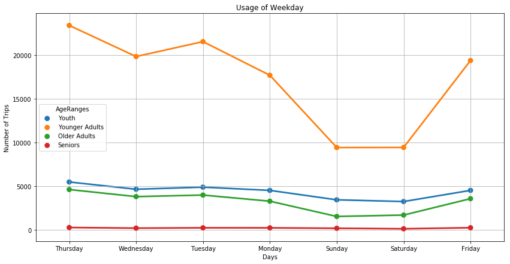

```python
plt.figure(figsize=[14, 7]);

df_classified_user_week = df.groupby(['start_time_day_name', 'AgeRanges']).size().reset_index()
weekday = df.start_time_day_name.unique()

ax = sb.pointplot(data=df_classified_user_week, x='start_time_day_name', y=0, hue = 'AgeRanges', order = weekday);

plt.title('Usage of Weekday');
plt.xlabel('Days')
plt.ylabel('Number of Trips');
plt.grid()
```

According to the above plot, The "Younger Adults" have the most number of trips through the weekdays, and "Youth" have the second most trips.

### Trips based on gender and weekdays?

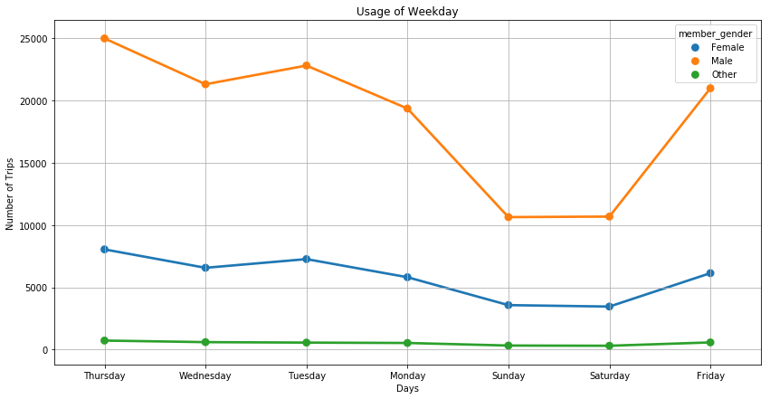

```python
plt.figure(figsize=[14, 7]);

df_classified_user_week = df.groupby(['start_time_day_name', 'member_gender']).size().reset_index()
weekday = df.start_time_day_name.unique()

ax = sb.pointplot(data=df_classified_user_week, x='start_time_day_name', y=0, hue = 'member_gender', order = weekday);

plt.title('Usage of Weekday');
plt.xlabel('Days')
plt.ylabel('Number of Trips');
plt.grid()
```

- Males users have larger numbers of trips throughout the days.

### Average duration trips on Weekdays for Member Gender

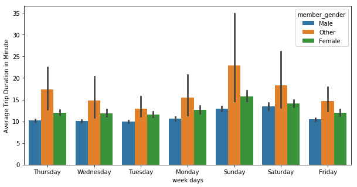

```python
plt.figure(figsize = [10, 5])
df['duration_min'] = (df.duration_sec/60).astype(int)
sb.barplot(data=df, x='start_time_day_name', y='duration_min', hue='member_gender');
plt.xlabel('week days');
plt.ylabel('Average Trip Duration in Minute');
```

- The **Other** members gender has the most average duration trips throughout all weekdays.